# Predictive Modeling with Linear Regression Project: ReCell

## Problem Statement

### Business Context

Buying and selling used phones and tablets used to be something that happened on a handful of online marketplace sites. But the used and refurbished device market has grown considerably over the past decade, and a new IDC (International Data Corporation) forecast predicts that the used phone market would be worth $52.7bn by 2023 with a compound annual growth rate (CAGR) of 13.6% from 2018 to 2023. This growth can be attributed to an uptick in demand for used phones and tablets that offer considerable savings compared with new models.

Refurbished and used devices continue to provide cost-effective alternatives to both consumers and businesses that are looking to save money when purchasing one. There are plenty of other benefits associated with the used device market. Used and refurbished devices can be sold with warranties and can also be insured with proof of purchase. Third-party vendors/platforms, such as Verizon, Amazon, etc., provide attractive offers to customers for refurbished devices. Maximizing the longevity of devices through second-hand trade also reduces their environmental impact and helps in recycling and reducing waste. The impact of the COVID-19 outbreak may further boost this segment as consumers cut back on discretionary spending and buy phones and tablets only for immediate needs.

### Objective

The rising potential of this comparatively under-the-radar market fuels the need for an ML-based solution to develop a dynamic pricing strategy for used and refurbished devices. ReCell, a startup aiming to tap the potential in this market, has hired you as a data scientist. They want you to analyze the data provided and build a linear regression model to predict the price of a used phone/tablet and identify factors that significantly influence it.

### Data Description

The data contains the different attributes of used/refurbished phones and tablets. The data was collected in the year 2021. The detailed data dictionary is given below.

- brand_name: Name of manufacturing brand
- os: OS on which the device runs
- screen_size: Size of the screen in cm
- 4g: Whether 4G is available or not
- 5g: Whether 5G is available or not
- main_camera_mp: Resolution of the rear camera in megapixels
- selfie_camera_mp: Resolution of the front camera in megapixels
- int_memory: Amount of internal memory (ROM) in GB
- ram: Amount of RAM in GB
- battery: Energy capacity of the device battery in mAh
- weight: Weight of the device in grams
- release_year: Year when the device model was released
- days_used: Number of days the used/refurbished device has been used
- normalized_new_price: Normalized price of a new device of the same model in euros
- normalized_used_price: Normalized price of the used/refurbished device in euros

## Problem Statement

There are a wide range of both numerical and qualitative variables. I need to find the most efficient predictor model for a phone's resale price on the used market.

## Importing necessary libraries

```python
"""
The code below generates an error when uncommented and run in Google Colab.  Specificially, the error states "subprocess-exited-with-error"
and that the issue is from the subprocess not pip.  As a result, current versions of all libraries will be installed and run.
"""

# Installing the libraries with the specified version.
# uncomment and run the following line if Google Colab is being used
# !pip install scikit-learn==1.2.2 seaborn==0.13.1 matplotlib==3.7.1 numpy==1.25.2 pandas==1.5.3 -q --user
```

```
'\nThe code below generates an error when uncommented and run in Google Colab.  Specificially, the error states "subprocess-exited-with-error"\nand that the issue is from the subprocess not pip.  As a result, current versions of all libraries will be installed and run.\n'
```

```python
# Installing the libraries with the specified version.
# uncomment and run the following lines if Jupyter Notebook is being used
# !pip install scikit-learn==1.2.2 seaborn==0.11.1 matplotlib==3.3.4 numpy==1.24.3 pandas==1.5.2 -q --user
```

**Note**: *After running the above cell, kindly restart the notebook kernel and run all cells sequentially from the start again.*

```python
import seaborn as sns
import matplotlib.pyplot as plt
import numpy as np
import pandas as pd

sns.set()

# split the data into train and test
from sklearn.model_selection import train_test_split

# to build linear regression_model
import statsmodels.api as sm

# to check model performance
from sklearn.metrics import mean_absolute_error, mean_squared_error, r2_score
```

## Loading the dataset

```python
from google.colab import drive
drive.mount('/content/drive')
```

```python
path = "/content/drive/MyDrive/UT DS Grad Cert/Project3/"
df = pd.read_csv(path + "used_device_data.csv")
```

```python
pd.set_option('display.max_colwidth', None)
pd.set_option('display.width', 1000) # Setting a very large width to prevent wrapping
```

## Data Overview

- Observations
- Sanity checks

```python
df.head()
```

|  | brand_name | os | screen_size | 4g | 5g | main_camera_mp | selfie_camera_mp | int_memory | ram | battery | weight | release_year | days_used | normalized_used_price | normalized_new_price |
| --- | --- | --- | --- | --- | --- | --- | --- | --- | --- | --- | --- | --- | --- | --- | --- |
| 0 | Honor | Android | 14.50 | yes | no | 13.0 | 5.0 | 64.0 | 3.0 | 3020.0 | 146.0 | 2020 | 127 | 4.307572 | 4.715100 |
| 1 | Honor | Android | 17.30 | yes | yes | 13.0 | 16.0 | 128.0 | 8.0 | 4300.0 | 213.0 | 2020 | 325 | 5.162097 | 5.519018 |
| 2 | Honor | Android | 16.69 | yes | yes | 13.0 | 8.0 | 128.0 | 8.0 | 4200.0 | 213.0 | 2020 | 162 | 5.111084 | 5.884631 |
| 3 | Honor | Android | 25.50 | yes | yes | 13.0 | 8.0 | 64.0 | 6.0 | 7250.0 | 480.0 | 2020 | 345 | 5.135387 | 5.630961 |
| 4 | Honor | Android | 15.32 | yes | no | 13.0 | 8.0 | 64.0 | 3.0 | 5000.0 | 185.0 | 2020 | 293 | 4.389995 | 4.947837 |

```python
#Look at shape of data and numeric summary
print(f"Shape: {df.shape}")
print(f"\nData Information\n")
print(f"{df.info()}")
print(f"\n {df.describe(include = "all").T}")
```

```
Shape: (3454, 15)

Data Information

<class 'pandas.core.frame.DataFrame'>
RangeIndex: 3454 entries, 0 to 3453
Data columns (total 15 columns):
 #   Column                 Non-Null Count  Dtype
---  ------                 --------------  -----
 0   brand_name             3454 non-null   object
 1   os                     3454 non-null   object
 2   screen_size            3454 non-null   float64
 3   4g                     3454 non-null   object
 4   5g                     3454 non-null   object
 5   main_camera_mp         3275 non-null   float64
 6   selfie_camera_mp       3452 non-null   float64
 7   int_memory             3450 non-null   float64
 8   ram                    3450 non-null   float64
 9   battery                3448 non-null   float64
 10  weight                 3447 non-null   float64
 11  release_year           3454 non-null   int64
 12  days_used              3454 non-null   int64
 13  normalized_used_price  3454 non-null   float64
 14  normalized_new_price   3454 non-null   float64
dtypes: float64(9), int64(2), object(4)
memory usage: 404.9+ KB
None

                         count unique      top  freq         mean          std       min       25%       50%       75%       max
brand_name               3454     34   Others   502          NaN          NaN       NaN       NaN       NaN       NaN       NaN
os                       3454      4  Android  3214          NaN          NaN       NaN       NaN       NaN       NaN       NaN
screen_size            3454.0    NaN      NaN   NaN    13.713115      3.80528      5.08      12.7     12.83     15.34     30.71
4g                       3454      2      yes  2335          NaN          NaN       NaN       NaN       NaN       NaN       NaN
5g                       3454      2       no  3302          NaN          NaN       NaN       NaN       NaN       NaN       NaN
main_camera_mp         3275.0    NaN      NaN   NaN     9.460208     4.815461      0.08       5.0       8.0      13.0      48.0
selfie_camera_mp       3452.0    NaN      NaN   NaN     6.554229     6.970372       0.0       2.0       5.0       8.0      32.0
int_memory             3450.0    NaN      NaN   NaN    54.573099    84.972371      0.01      16.0      32.0      64.0    1024.0
ram                    3450.0    NaN      NaN   NaN     4.036122     1.365105      0.02       4.0       4.0       4.0      12.0
battery                3448.0    NaN      NaN   NaN  3133.402697  1299.682844     500.0    2100.0    3000.0    4000.0    9720.0
weight                 3447.0    NaN      NaN   NaN   182.751871    88.413228      69.0     142.0     160.0     185.0     855.0
release_year           3454.0    NaN      NaN   NaN  2015.965258     2.298455    2013.0    2014.0    2015.5    2018.0    2020.0
days_used              3454.0    NaN      NaN   NaN   674.869716   248.580166      91.0     533.5     690.5    868.75    1094.0
normalized_used_price  3454.0    NaN      NaN   NaN     4.364712     0.588914  1.536867  4.033931  4.405133    4.7557  6.619433
normalized_new_price   3454.0    NaN      NaN   NaN     5.233107     0.683637  2.901422  4.790342  5.245892  5.673718  7.847841
```

#### Observations

**Data Description**

**Data Summary**

Our target variable is normalized_used_price. The normalized mean price (in Euros) is €4.364712 with a range from €1.53687 to €6.619433. The other numeric variables will be described in the exploratory data analysis section. The wide range of phone brands means that the most common brand is "others". The most common os is Android and the most common cell service is 4g.

## Exploratory Data Analysis (EDA)

- The goal of this EDA is to understand the data, both as individual variables and in relation to each other.
- The following questions will be addressed:
  - What does the distribution of normalized used device prices look like?
  - What percentage of the used device market is dominated by Android devices?
  - The amount of RAM is important for the smooth functioning of a device. How does the amount of RAM vary with the brand?
  - A large battery often increases a device's weight, making it feel uncomfortable in the hands. How does the weight vary for phones and tablets offering large batteries (more than 4500 mAh)?
  - Bigger screens are desirable for entertainment purposes as they offer a better viewing experience. How many phones and tablets are available across different brands with a screen size larger than 6 inches?
  - A lot of devices nowadays offer great selfie cameras, allowing us to capture our favorite moments with loved ones. What is the distribution of devices offering greater than 8MP selfie cameras across brands?
  - Which attributes are highly correlated with the normalized price of a used device?

### Basic EDA - Univariate Analysis

```python
def histogram_boxplot(data, feature, figsize=(15, 10), kde=False, bins=None):
    """
    Boxplot and histogram combined

    data: dataframe
    feature: dataframe column
    figsize: size of figure (default (15,10))
    kde: whether to show the density curve (default False)
    bins: number of bins for histogram (default None)
    """
    f2, (ax_box2, ax_hist2) = plt.subplots(
        nrows=2,  # Number of rows of the subplot grid= 2
        sharex=True,  # x-axis will be shared among all subplots
        gridspec_kw={"height_ratios": (0.25, 0.75)},
        figsize=figsize,
    )  # creating the 2 subplots
    sns.boxplot(
        data=data, x=feature, ax=ax_box2, showmeans=True, color="violet"
    )  # boxplot will be created and a triangle will indicate the mean value of the column
    sns.histplot(
        data=data, x=feature, kde=kde, ax=ax_hist2, bins=bins
    ) if bins else sns.histplot(
        data=data, x=feature, kde=kde, ax=ax_hist2
    )  # For histogram
    ax_hist2.axvline(
        data[feature].mean(), color="green", linestyle="--"
    )  # Add mean to the histogram
    ax_hist2.axvline(
        data[feature].median(), color="black", linestyle="-"
    )  # Add median to the histogram

    # function to create labeled barplots


def labeled_barplot(data, feature, perc=False, n=None, order=None):
    """
    Barplot with percentage at the top

    data: dataframe
    feature: dataframe column
    perc: whether to display percentages instead of count (default is False)
    n: displays the top n category levels (default is None, i.e., display all levels)
    order: order of bars (default is None, i.e., sorted by count in descending order)
    """

    total = len(data[feature])  # length of the column
    count = data[feature].nunique()
    if n is None:
        plt.figure(figsize=(count + 2, 6))
    else:
        plt.figure(figsize=(n + 2, 6))

    plt.xticks(rotation=90, fontsize=15)
    ax = sns.countplot(
        data=data,
        x=feature,
        hue=feature,
        palette="Paired",
        order=order if order is not None else data[feature].value_counts().index[:n],
    )

    for p in ax.patches:
        if perc == True:
            label = "{:.1f}%".format(
                100 * p.get_height() / total
            )  # percentage of each class of the category
        else:
            label = p.get_height()  # count of each level of the category

        x = p.get_x() + p.get_width() / 2  # width of the plot
        y = p.get_height()  # height of the plot

        ax.annotate(
            label,
            (x, y),
            ha="center",
            va="center",
            size=12,
            xytext=(0, 5),
            textcoords="offset points",
        )  # annotate the percentage

    plt.show()  # show the plot
```

#### `Screen Size`

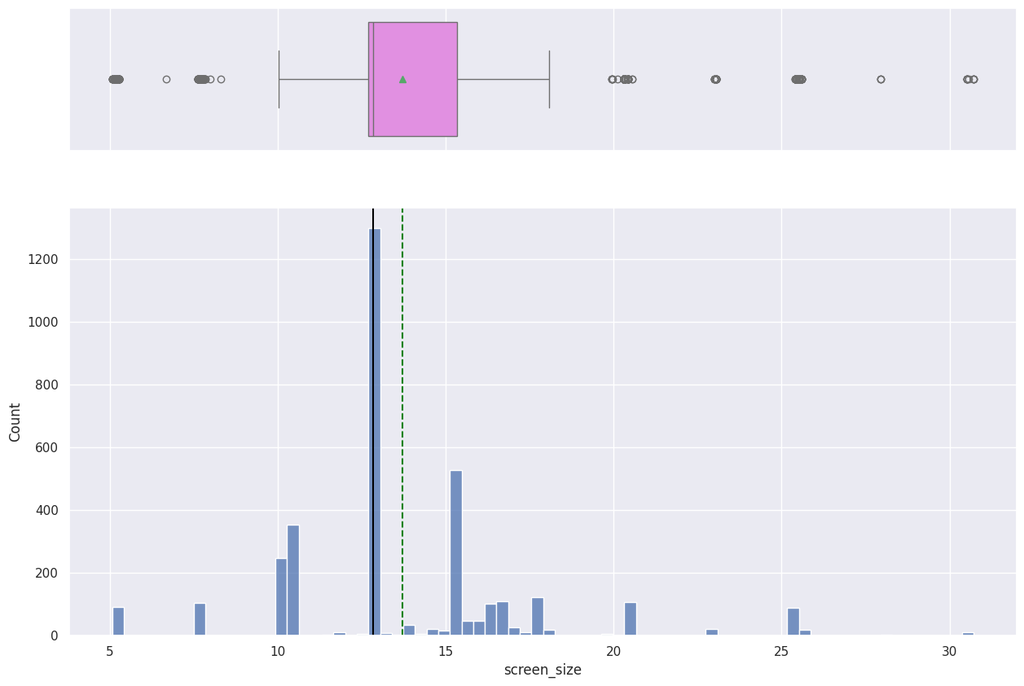

```python
histogram_boxplot(df,"screen_size")
```

Screen size is right skewed with a large number of outliers in each tail. This is predominately due to the overwhelmingly large count near the median of the data set.

#### `Main Camera mp`

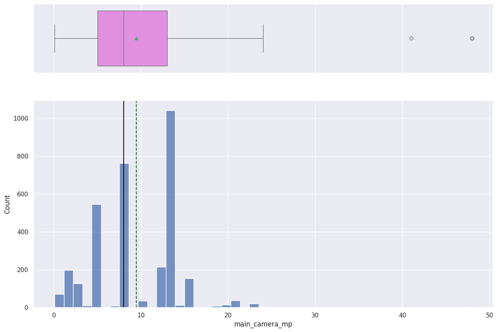

```python
histogram_boxplot(df,"main_camera_mp")
```

Main_camera_mp is right skewed with two outliers at the large end that must be considered.

#### `selfie_camera_mp`

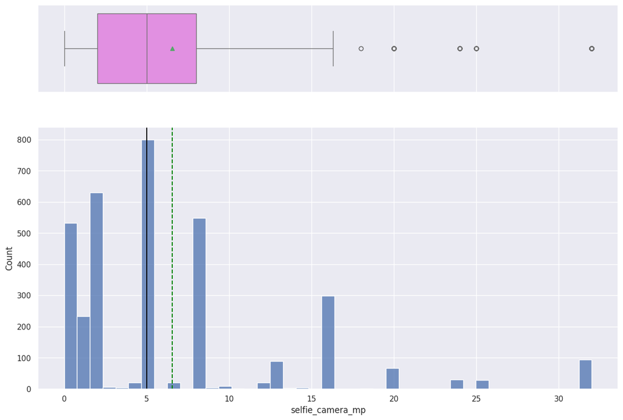

```python
histogram_boxplot(df,"selfie_camera_mp")
```

Selfie_camera_mp is also right skewed with several outliers on the high end that should be explored.

#### `int_memory`

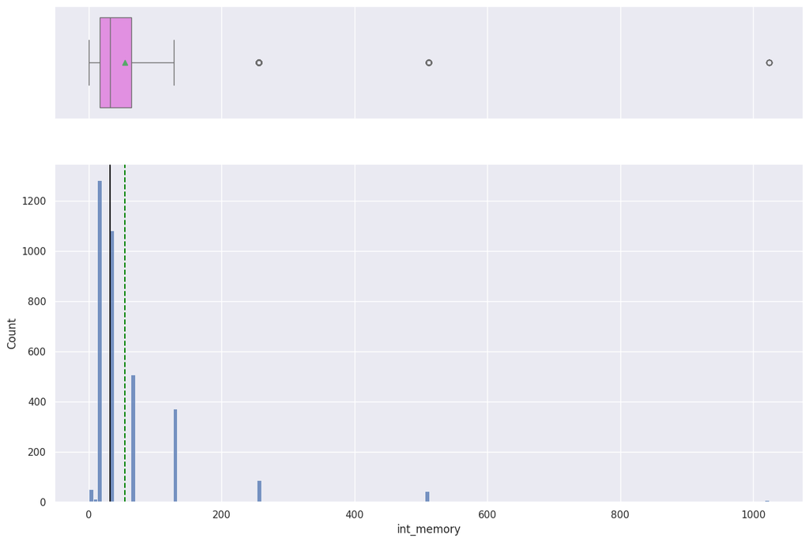

```python
histogram_boxplot(df,"int_memory")
```

Internal memory is also right skewed with some very large outliers.

#### `ram`

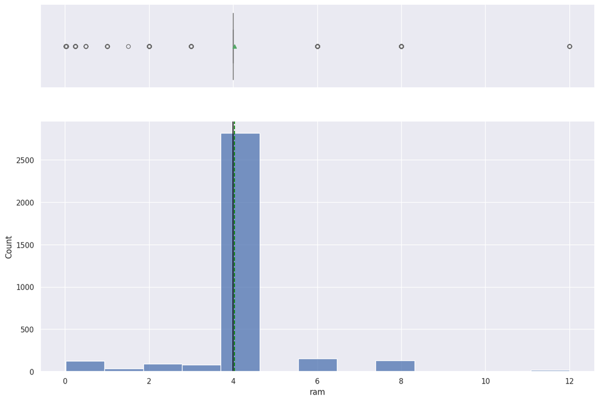

```python
histogram_boxplot(df,"ram")
```

Phones with 4GB of ram are so overwhelmingly common that all other ram counts appear as outliers. Since ram is discrete for this variable, it may be beneficial to consider this as a categorical data, rather than numeric.

#### `battery`

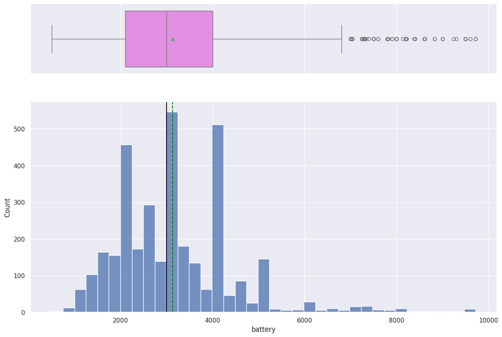

```python
histogram_boxplot(df,"battery")
```

Battery data is right skewed with high end outliers, none of which seem problematic.

#### `weight`

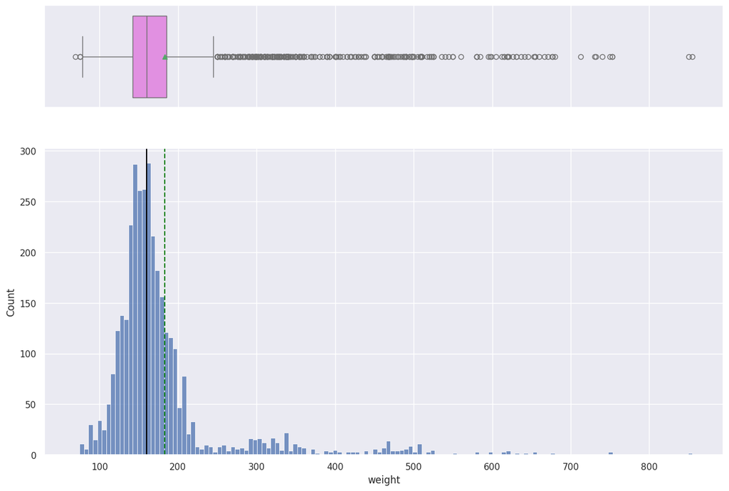

```python
histogram_boxplot(df,"weight")
```

Weight is very right skewed but no unusual looking outliers.

#### `days used`

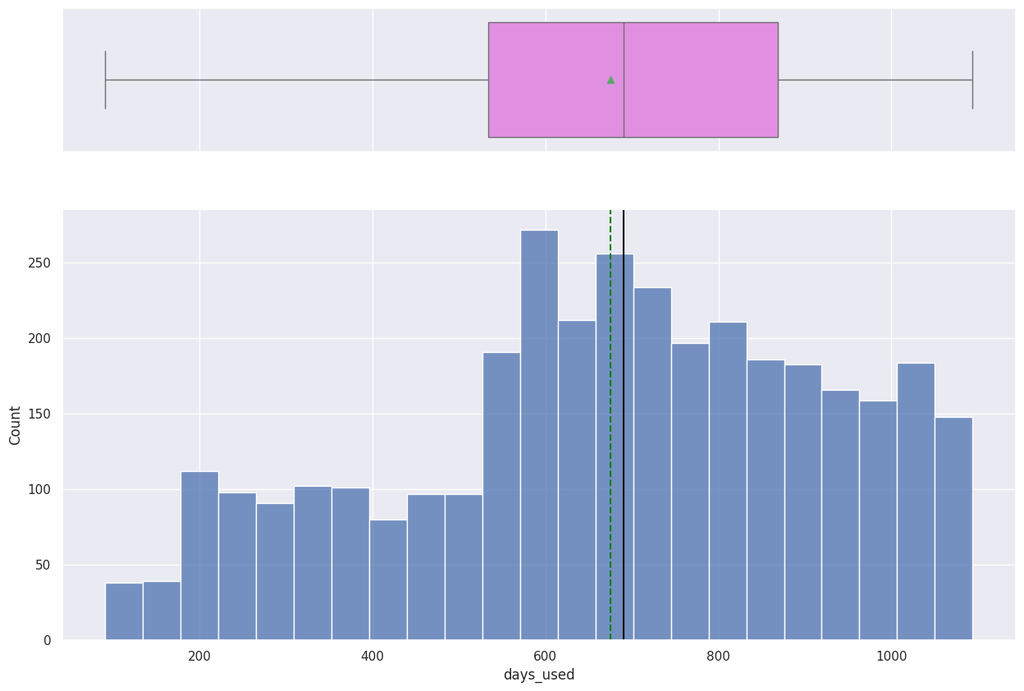

```python
histogram_boxplot(df,"days_used")
```

Days used is slightly left skewed with no outliers.

#### `normalized_new_price`

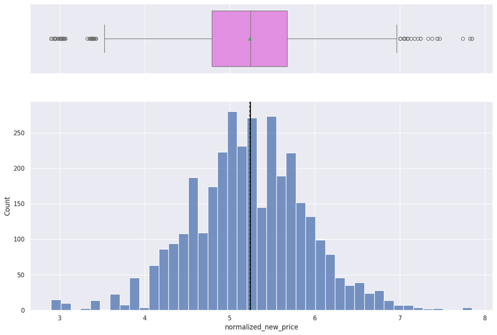

```python
histogram_boxplot(df,"normalized_new_price")
```

Normalized new price is (not surprisingly) normally distributed with outliers on both ends.

#### `normalized_used_price`

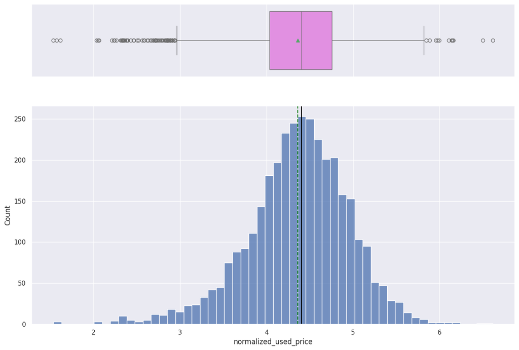

```python
histogram_boxplot(df,"normalized_used_price")
```

This is our target variable. It is slightly left skewed with the mean being less than the median.

#### `os`

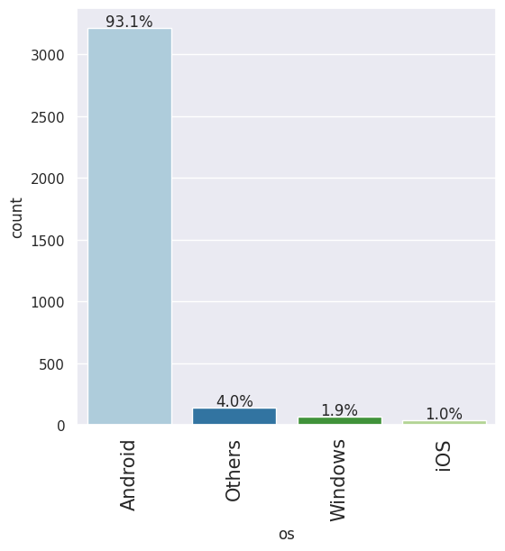

```python
labeled_barplot(df,"os", perc = True)
```

The vast majority of phones (93.1%) are on the Android OS.

#### `Brand Name`

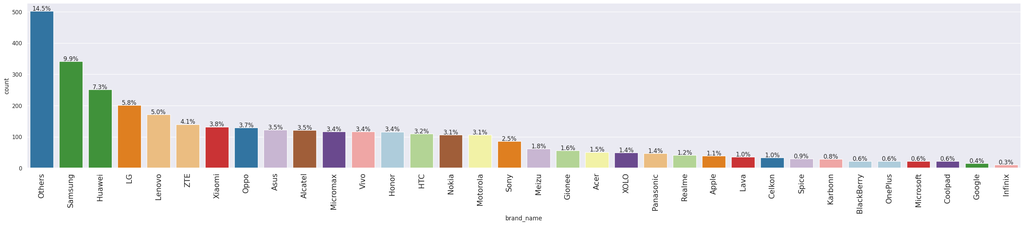

```python
labeled_barplot(df,"brand_name", perc = True)
```

Due to the prevalance of many different brands, "other" is the most common at 14.5%. Of the recorded brands, Samsung is the most popular at 9.9%.

#### `4G`

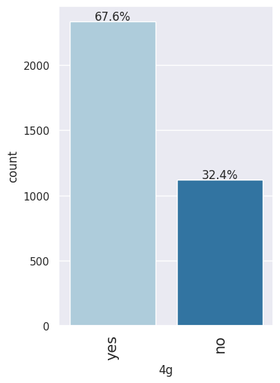

```python
labeled_barplot(df,"4g", perc = True)
```

Two-thirds of the phones have 4G service.

#### `5G`

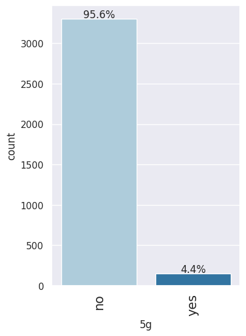

```python
labeled_barplot(df,"5g", perc = True)
```

Very few of the phones (only 4.4%) have 5G service.

#### `Release Year`

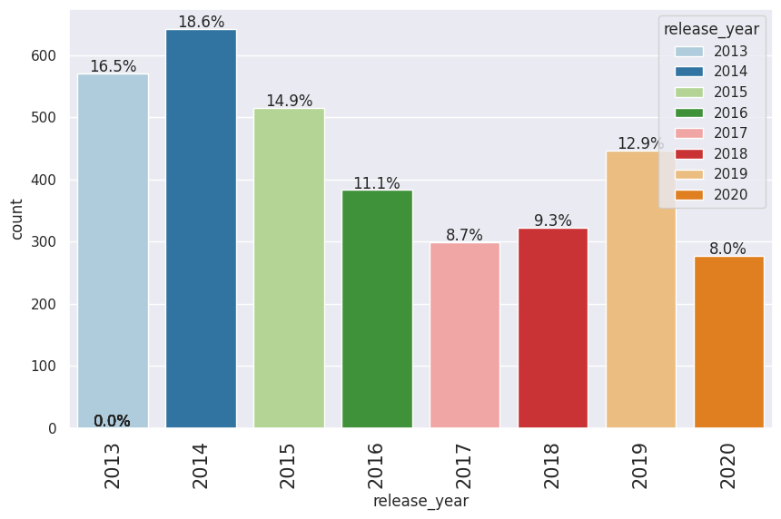

```python
labeled_barplot(df,"release_year", perc = True, order=sorted(df["release_year"].unique()))
```

Older phones are more common in this data set in general.

#### `RAM`

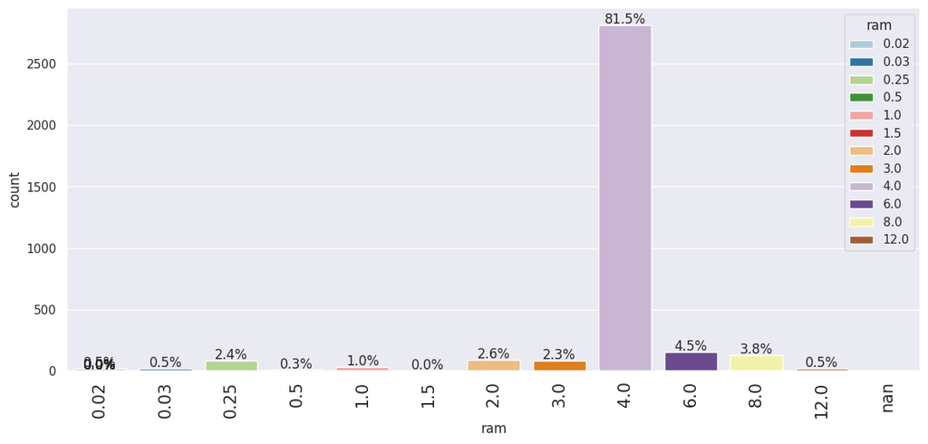

```python
labeled_barplot(df,"ram", perc = True, order=sorted(df["ram"].unique()))
```

As explained above, it may be worth treating ram as a categorical varible since it is (mostly) a discrete set of values. As suggested by the numerical analysis above, 4.0GB of ram is by far the most commonly occuring type.

### Basic EDA - Bivariate Analysis

#### Correlation Analysis

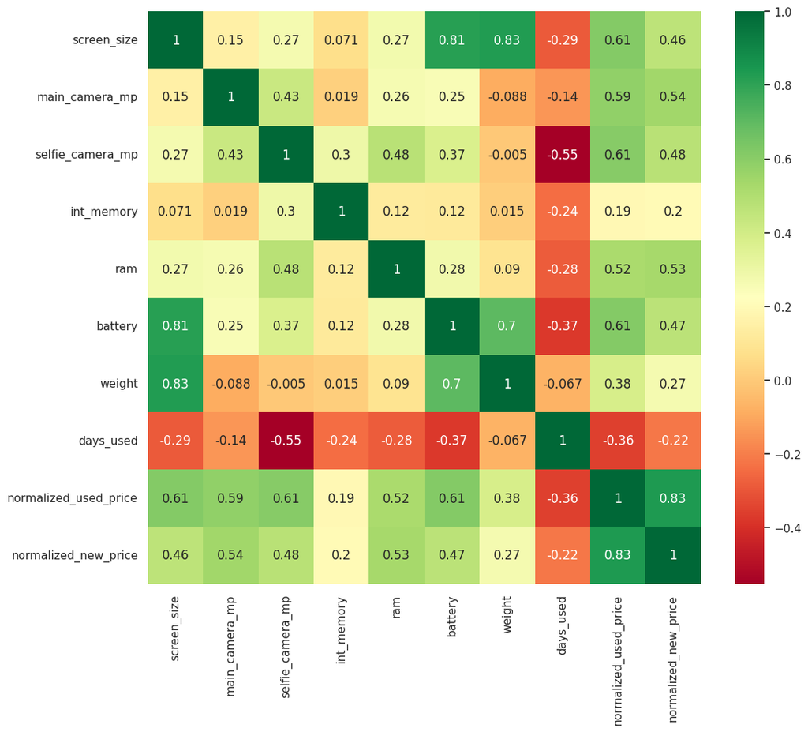

```python
#Pulling out the numerical columns
num_cols = df.select_dtypes(include=np.number).columns.tolist()

#dropping Year released
num_cols.remove('release_year')

#create a correlation heatmap for the numeric columns
plt.figure(figsize=(12, 10))
sns.heatmap(df[num_cols].corr(), annot=True, cmap = "RdYlGn")
plt.show()
```

The target variable, normalized_used_price is positively correlated with most of the other variables:

- moderately correlated with screen_size, main_camera_mp, selfie_camera_mp, ram, and battery.
- weakly correlated with int_memory and weight
- strongly correlated with normalized_new_price

It is weakly negatively correlated with days_used.

=================================

**N.B.**: Correlation interpretation using language is notoriously imprecise. The only accepted convention is that values closer to ±1 are strong and values close to 0 are not correlated. I typically use the following convention:

- |r|≥0.9: very strong
- |r|≥0.8: strong
- |r|≥0.5: moderate
- |r|≥0.15: weak
- |r|<0.15: no correlation

```python
# View ram by brand
df.groupby('brand_name')['ram'].value_counts()
```

| brand_name | ram | count |
| --- | --- | --- |
| Acer | 4.00 | 49 |
|  | 1.00 | 1 |
|  | 2.00 | 1 |
| Alcatel | 4.00 | 98 |
|  | 1.00 | 10 |
| ... | ... | ... |
| ZTE | 2.00 | 3 |
|  | 3.00 | 3 |
|  | 8.00 | 3 |
|  | 1.00 | 2 |
|  | 0.25 | 1 |

143 rows × 1 columns

**dtype:** int64

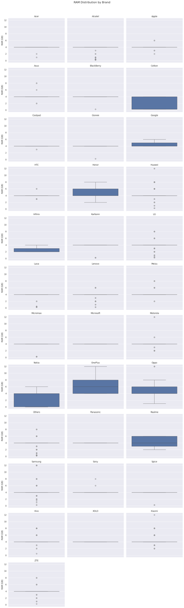

```python
#view boxplots of ram sorted by brand

# Get unique brand names and sort them alphabetically
brands = sorted(df['brand_name'].unique())
num_brands = len(brands)

# Calculate the number of columns needed for a 3 column grid
num_cols = 3
num_rows = (num_brands + num_cols - 1) // num_cols  # Ceiling division

# Create the figure and subplots
fig, axes = plt.subplots(num_rows, num_cols, figsize=(5 * num_cols, 4 * num_rows), sharey=True)
axes = axes.flatten() # Flatten the 2D array of axes for easy iteration

# Iterate through each brand and create a boxplot
for i, brand in enumerate(brands):
    sns.boxplot(y=df[df['brand_name'] == brand]['ram'], ax=axes[i])
    axes[i].set_title(brand)
    axes[i].set_xlabel('') # Remove x-axis label for clarity
    axes[i].set_ylabel('RAM (GB)')

# Hide any unused subplots
for j in range(i + 1, len(axes)):
    fig.delaxes(axes[j])

plt.tight_layout()
plt.suptitle('RAM Distribution by Brand', y=1.02, fontsize=16)
plt.show()
```

#### Observations on RAM by brand

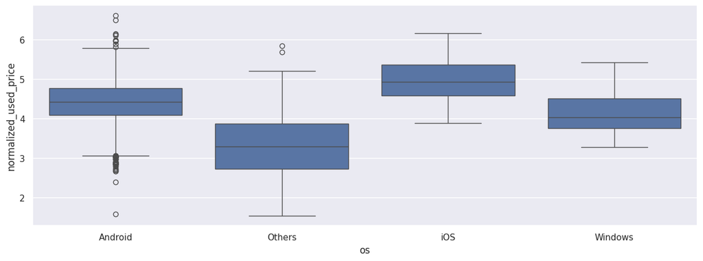

```python
#Price distribtution by operating system
plt.figure(figsize = (15,5))
sns.boxplot(x = "os", y = "normalized_used_price", data = df)
plt.show()
```

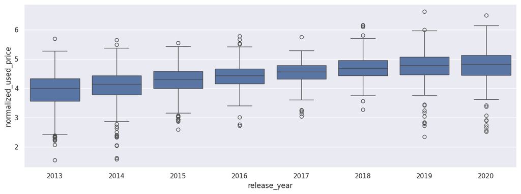

```python
#price by year released
plt.figure(figsize = (15,5))
sns.boxplot(x = "release_year", y = "normalized_used_price", data = df)
plt.show()
```

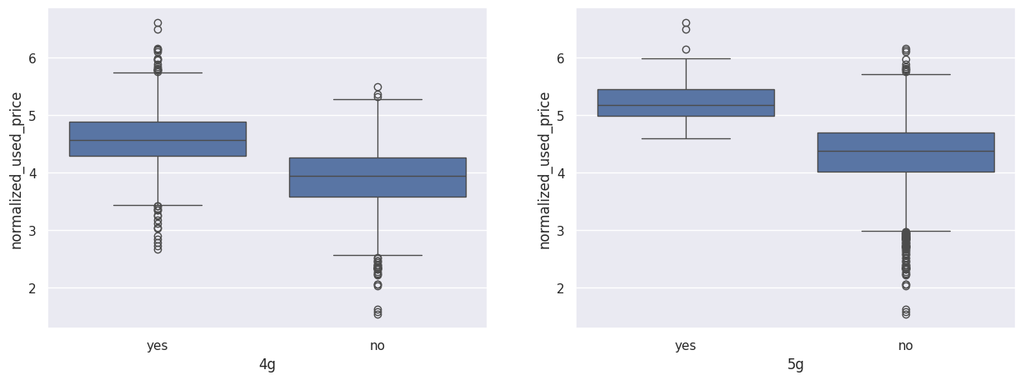

```python
plt.figure(figsize = (15,5))

plt.subplot(1,2,1)
sns.boxplot(x = "4g", y = "normalized_used_price", data = df, order=["yes","no"])
plt.subplot(1,2,2)
sns.boxplot(x = "5g", y = "normalized_used_price", data = df, order = ["yes", "no"])
plt.show()
```

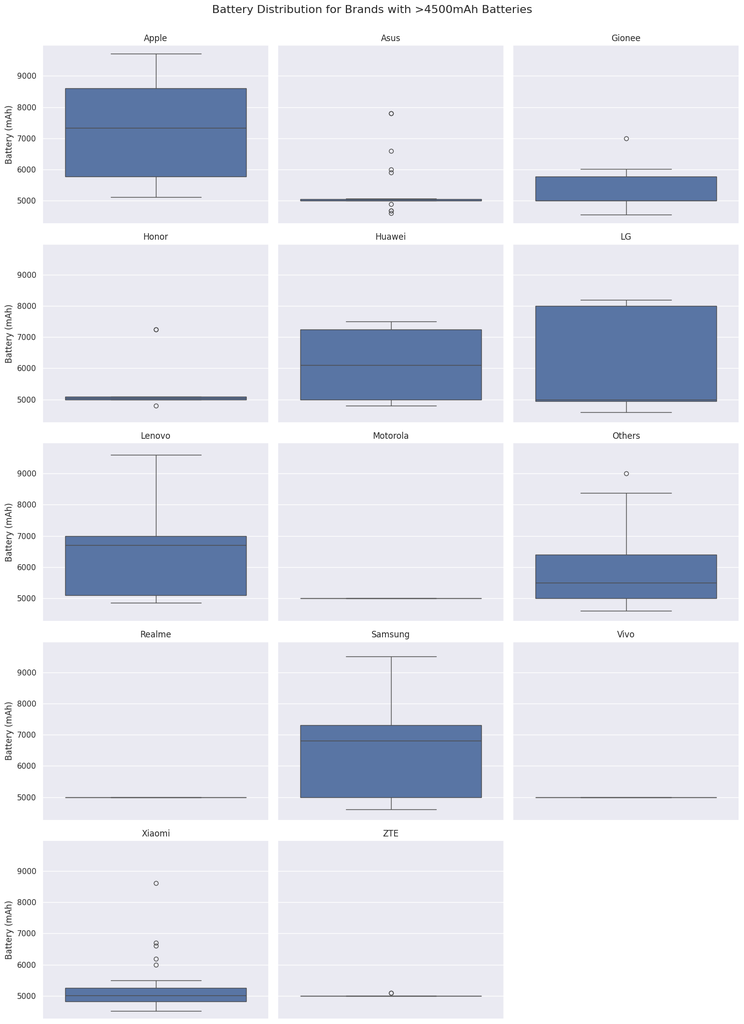

```python
df_battery = df[df['battery']>4500]
df_battery.shape

#I had many boxplots with small values in them so I am reducing the number of boxplots for clarity
df_battery["brand_name"].value_counts()
brand_counts = df_battery['brand_name'].value_counts()
brands_with_10_or_more = sorted(brand_counts[brand_counts >= 10].index.tolist())
# print(brands_with_10_or_more)

# Get all unique brand names from df_battery
brands = sorted(df_battery['brand_name'].unique())
num_brands = len(brands_with_10_or_more)

# Define grid dimensions
num_cols = 3
num_rows = (num_brands + num_cols - 1) // num_cols # Ceiling division

# Create the figure and subplots
fig, axes = plt.subplots(num_rows, num_cols, figsize=(5 * num_cols, 4 * num_rows), sharey=True)
axes = axes.flatten() # Flatten the 2D array of axes for easy iteration

# Iterate through each brand and create a boxplot
for i, brand in enumerate(brands_with_10_or_more):
    sns.boxplot(y=df_battery[df_battery['brand_name'] == brand]['battery'], ax=axes[i])
    axes[i].set_title(brand)
    axes[i].set_xlabel('') # Remove x-axis label for clarity
    axes[i].set_ylabel('Battery (mAh)')

# Hide any unused subplots
for j in range(i + 1, len(axes)):
    fig.delaxes(axes[j])

plt.tight_layout()
plt.suptitle('Battery Distribution for Brands with >4500mAh Batteries', y=1.02, fontsize=16)
plt.show()
```

#### Observations on large battery by brand

Overall, Apple phones were the brand with the largest battery size overall. While this suggests the phones may have a longer life between charges, the offset for this is a heavier phone.

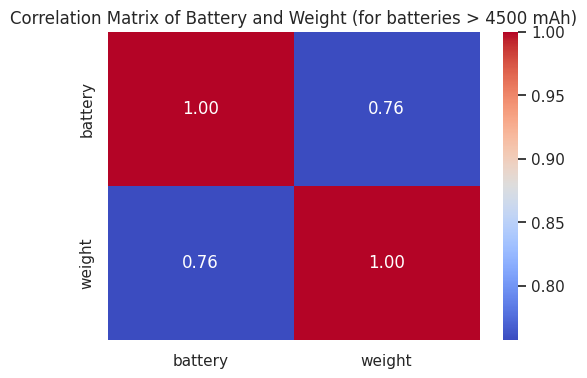

```python
# create a correlation matrix of battery size and weight for the >4500 dataset

# Select the 'battery' and 'weight' columns from df_battery
battery_weight_df = df_battery[['battery', 'weight']]

# Calculate the correlation matrix
correlation_matrix = battery_weight_df.corr()

# Plot the heatmap
plt.figure(figsize=(6, 4))
sns.heatmap(correlation_matrix, annot=True, cmap='coolwarm', fmt=".2f")
plt.title('Correlation Matrix of Battery and Weight (for batteries > 4500 mAh)')
plt.show()
```

```python
print("Correlations between Battery and Weight per Brand (for devices with Battery > 4500 mAh):")

# Get unique brands from df_battery
brands_in_df_battery = df_battery['brand_name'].unique()

correlation_data = {} # Initialize dictionary to store correlations

# Iterate through each brand and calculate the correlation
for brand in sorted(brands_in_df_battery):
    brand_df = df_battery[df_battery['brand_name'] == brand][['battery', 'weight']]

    # Only calculate correlation if there are at least two rows and sufficient variation
    if len(brand_df) > 1:
        # Check for zero standard deviation to avoid RuntimeWarning
        if brand_df['battery'].std() == 0 or brand_df['weight'].std() == 0:
            print(f"  {brand}: Not enough variation in battery or weight for correlation")
            correlation_data[brand] = float('nan') # Store NaN for no variation
        else:
            correlation = brand_df['battery'].corr(brand_df['weight'])
            print(f"  {brand}: {correlation:.2f}")
            correlation_data[brand] = round(correlation, 2) # Store rounded correlation
    else:
        print(f"  {brand}: Not enough data for correlation")
        correlation_data[brand] = float('nan') # Store NaN for insufficient data

correlation_df = pd.DataFrame.from_dict(correlation_data, orient='index', columns=['Correlation']).sort_index()

display(correlation_df.dropna())
```

```
Correlations between Battery and Weight per Brand (for devices with Battery > 4500 mAh):
  Acer: 0.39
  Alcatel: Not enough data for correlation
  Apple: 0.82
  Asus: 0.50
  Gionee: 0.39
  Google: Not enough data for correlation
  HTC: Not enough data for correlation
  Honor: 0.85
  Huawei: 0.68
  Infinix: 1.00
  LG: 0.90
  Lenovo: 0.90
  Micromax: Not enough data for correlation
  Motorola: Not enough variation in battery or weight for correlation
  Nokia: Not enough data for correlation
  Oppo: Not enough variation in battery or weight for correlation
  Others: 0.68
  Panasonic: Not enough data for correlation
  Realme: Not enough variation in battery or weight for correlation
  Samsung: 0.75
  Sony: Not enough variation in battery or weight for correlation
  Spice: Not enough data for correlation
  Vivo: Not enough variation in battery or weight for correlation
  Xiaomi: 0.92
  ZTE: 0.49
```

|  | Correlation |
| --- | --- |
| Acer | 0.39 |
| Apple | 0.82 |
| Asus | 0.50 |
| Gionee | 0.39 |
| Honor | 0.85 |
| Huawei | 0.68 |
| Infinix | 1.00 |
| LG | 0.90 |
| Lenovo | 0.90 |
| Others | 0.68 |
| Samsung | 0.75 |
| Xiaomi | 0.92 |
| ZTE | 0.49 |

### Visualization of Battery-Weight Correlation by Brand

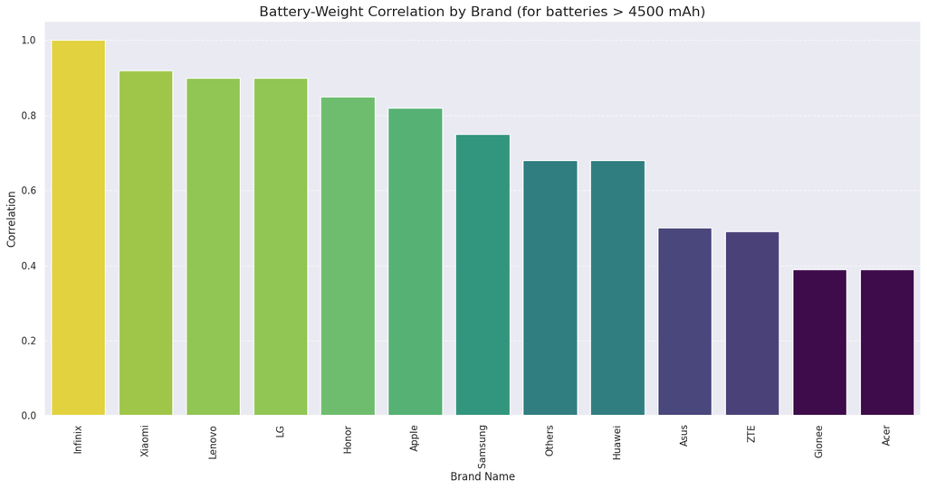

```python
# Filter out NaN values and sort the correlations from strongest to weakest
correlation_for_plot = correlation_df.dropna().sort_values(by='Correlation', ascending=False)

plt.figure(figsize=(15, 8))

# Create a color map for the bars based on their correlation value
# Normalize correlation values to the [0, 1] range of the colormap
min_corr = correlation_for_plot['Correlation'].min()
max_corr = correlation_for_plot['Correlation'].max()

# Avoid division by zero if all correlations are the same
if max_corr == min_corr:
    colors = [plt.cm.viridis(0.5)] * len(correlation_for_plot) # Assign a middle color if no variation
else:
    normalized_correlations = (correlation_for_plot['Correlation'] - min_corr) / (max_corr - min_corr)
    colors = normalized_correlations.apply(lambda x: plt.cm.viridis(x))

sns.barplot(
    x=correlation_for_plot.index,
    y='Correlation',
    data=correlation_for_plot,
    hue=correlation_for_plot.index, # Assign x to hue as suggested by the warning
    palette=list(colors),
    legend=False # Set legend to False for the same effect as prior usage
)

plt.axhline(0, color='black', linewidth=0.8) # Add a horizontal line at y=0
plt.title('Battery-Weight Correlation by Brand (for batteries > 4500 mAh)', fontsize=16)
plt.xlabel('Brand Name', fontsize=12)
plt.ylabel('Correlation', fontsize=12)
plt.xticks(rotation=90) # Rotate brand names for readability
plt.grid(axis='y', linestyle='--', alpha=0.7)
plt.tight_layout()
plt.show()
```

```python
#pull phones with screens bigger than 6 inches
# note: the data is in cm, so converting at 2.54cm to inch
df_bigscreen = df[df['screen_size']>(6 * 2.54)]
df_bigscreen.shape
```

```
(1099, 15)
```

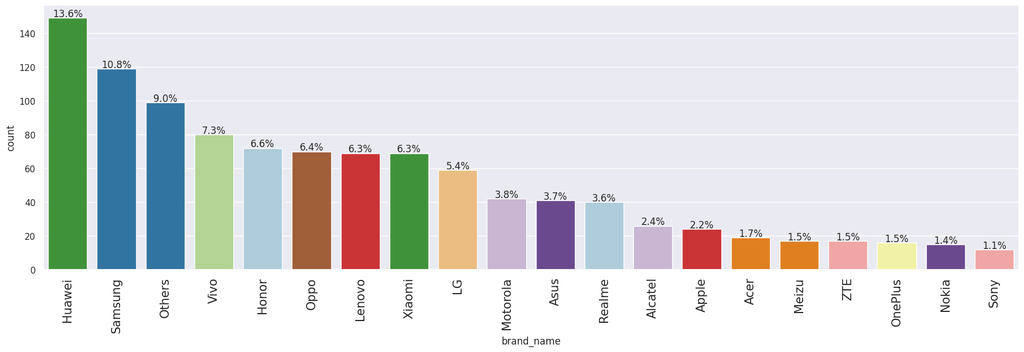

```python
#only displaying the top 20 brands
labeled_barplot(df_bigscreen,"brand_name", perc = True, n=20)
```

```python
#selfie cameras with more than 8mp
df_selfiecamera = df[df['selfie_camera_mp']>8]
df_selfiecamera.shape
```

```
(655, 15)
```

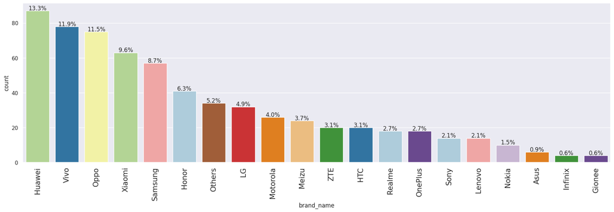

```python
labeled_barplot(df_selfiecamera,"brand_name", perc = True, n=20)
```

```python
#main cameras >16
df_maincamera = df[df['main_camera_mp']>16]
df_maincamera.shape
```

```
(94, 15)
```

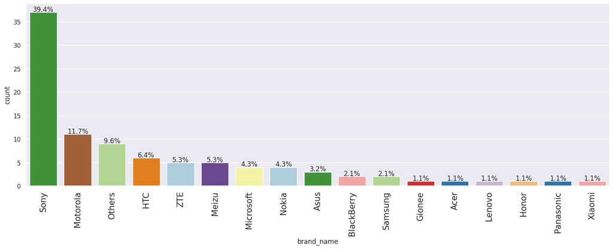

```python
labeled_barplot(df_maincamera,"brand_name", perc = True)
```

## Data Preprocessing

- Missing value treatment
- Feature engineering (if needed)
- Outlier detection and treatment (if needed)
- Preparing data for modeling
- Any other preprocessing steps (if needed)

### Missing Values Check

```python
#Check for duplicates
df.duplicated().sum()
```

```
np.int64(0)
```

There are no duplicated values.

```python
#check for missing values
df.isnull().sum()
```

|  | 0 |
| --- | --- |
| brand_name | 0 |
| os | 0 |
| screen_size | 0 |
| 4g | 0 |
| 5g | 0 |
| main_camera_mp | 179 |
| selfie_camera_mp | 2 |
| int_memory | 4 |
| ram | 4 |
| battery | 6 |
| weight | 7 |
| release_year | 0 |
| days_used | 0 |
| normalized_used_price | 0 |
| normalized_new_price | 0 |

**dtype:** int64

#### Observations

There are 179 missing values in main_camera_mp, 2 from selfie_camera_mp, 4 from int_memory, 4 from ram, 6 from battery, and 7 from weight.

```python
#Looking at the two categorical columns for odd data
print("Counts for 'brand_name':\n")
print(df['brand_name'].value_counts())
print("\n---\n")
print("Counts for 'os':\n")
print(df['os'].value_counts())
```

```
Counts for 'brand_name':

brand_name
Others        502
Samsung       341
Huawei        251
LG            201
Lenovo        171
ZTE           140
Xiaomi        132
Oppo          129
Asus          122
Alcatel       121
Micromax      117
Vivo          117
Honor         116
HTC           110
Nokia         106
Motorola      106
Sony           86
Meizu          62
Gionee         56
Acer           51
XOLO           49
Panasonic      47
Realme         41
Apple          39
Lava           36
Celkon         33
Spice          30
Karbonn        29
BlackBerry     22
OnePlus        22
Microsoft      22
Coolpad        22
Google         15
Infinix        10
Name: count, dtype: int64

---

Counts for 'os':

os
Android    3214
Others      137
Windows      67
iOS          36
Name: count, dtype: int64
```

```python
print(df['4g'].value_counts())
print(df['5g'].value_counts())
```

```
4g
yes    2335
no     1119
Name: count, dtype: int64
5g
no     3302
yes     152
Name: count, dtype: int64
```

#### Observations

There does not seem to be anything abnormal in the categorical columns.

### Exploring Missing Values

Before imputing the missing values blindly, I am checking to see if particular entries have multiple missing values.

```python
df[df['ram'].isnull()]
```

|  | brand_name | os | screen_size | 4g | 5g | main_camera_mp | selfie_camera_mp | int_memory | ram | battery | weight | release_year | days_used | normalized_used_price | normalized_new_price |
| --- | --- | --- | --- | --- | --- | --- | --- | --- | --- | --- | --- | --- | --- | --- | --- |
| 114 | Nokia | Others | 5.18 | no | no | 0.3 | 0.0 | 0.06 | NaN | 1020.0 | 91.3 | 2020 | 288 | 2.729159 | 2.911263 |
| 335 | Nokia | Others | 5.18 | no | no | 0.3 | 0.0 | 0.10 | NaN | 1200.0 | 88.2 | 2020 | 327 | 3.062924 | 3.689129 |
| 2059 | Nokia | Others | 5.18 | no | no | 0.3 | 0.0 | 0.06 | NaN | NaN | 82.6 | 2016 | 1023 | 2.765060 | 3.657905 |
| 2090 | Nokia | Others | 7.62 | no | no | 5.0 | 0.0 | 0.06 | NaN | 1200.0 | 111.4 | 2013 | 1001 | 3.827771 | 4.605770 |

```python
df[df['selfie_camera_mp'].isnull()]
```

|  | brand_name | os | screen_size | 4g | 5g | main_camera_mp | selfie_camera_mp | int_memory | ram | battery | weight | release_year | days_used | normalized_used_price | normalized_new_price |
| --- | --- | --- | --- | --- | --- | --- | --- | --- | --- | --- | --- | --- | --- | --- | --- |
| 1080 | Google | Android | 15.32 | yes | no | 12.2 | NaN | 64.0 | 4.0 | 3430.0 | 184.0 | 2018 | 475 | 5.573826 | 6.865974 |
| 1081 | Google | Android | 12.83 | yes | no | 12.2 | NaN | 64.0 | 4.0 | 2915.0 | 148.0 | 2018 | 424 | 4.464988 | 6.745083 |

```python
df[df['battery'].isnull()]
```

|  | brand_name | os | screen_size | 4g | 5g | main_camera_mp | selfie_camera_mp | int_memory | ram | battery | weight | release_year | days_used | normalized_used_price | normalized_new_price |
| --- | --- | --- | --- | --- | --- | --- | --- | --- | --- | --- | --- | --- | --- | --- | --- |
| 1829 | Meizu | Android | 12.83 | yes | no | 13.0 | 5.0 | 16.00 | 4.00 | NaN | 145.0 | 2014 | 986 | 4.177919 | 4.863604 |
| 1831 | Meizu | Android | 12.83 | yes | no | 20.7 | 5.0 | 16.00 | 4.00 | NaN | 158.0 | 2014 | 1043 | 4.878855 | 5.990639 |
| 1832 | Meizu | Android | 13.61 | yes | no | 20.7 | 2.0 | 16.00 | 4.00 | NaN | 147.0 | 2014 | 1007 | 4.742320 | 5.826118 |
| 1962 | Microsoft | Windows | 25.55 | no | no | 5.0 | 3.5 | 32.00 | 4.00 | NaN | 675.9 | 2013 | 931 | 5.230574 | 5.802753 |
| 2058 | Nokia | Others | 5.18 | no | no | 0.3 | 0.0 | 0.06 | 0.02 | NaN | 81.0 | 2016 | 815 | 2.718660 | 3.374511 |
| 2059 | Nokia | Others | 5.18 | no | no | 0.3 | 0.0 | 0.06 | NaN | NaN | 82.6 | 2016 | 1023 | 2.765060 | 3.657905 |

```python
#Copying the data frame
my_data = df.copy()
```

```python
# For all other missing values, I will use the median method to fill the missing data
# Impute missing values with the median for numerical columns
#since brand name and release year have an impact on the type of ram, battery size, camera size, etc
# I will replace missing values grouped by brand and release year
has_missing = ['main_camera_mp', 'selfie_camera_mp', 'int_memory', 'ram', 'battery', 'weight']
for col in has_missing:
    if my_data[col].isnull().any():
        # First attempt to fill using median grouped by brand_name and release_year
        median_val_grouped = my_data.groupby(["brand_name", "release_year"])[col].transform('median')
        my_data.fillna({col: median_val_grouped}, inplace=True)
        print(f"Missing data in {col} is {my_data[col].isnull().sum()}\n")

        # Second pass: there are still many NaNs so I will fill with the overall median of that brand.
        if my_data[col].isnull().any():
            brand_median = my_data.groupby(['brand_name'])[col].transform('median')
            my_data.fillna({col: brand_median}, inplace=True)
            print(f"Missing data on 2nd pass in {col} is {my_data[col].isnull().sum()}\n")

            # Third pass: the 10 remaining NaNs will fill with the overall median
            if my_data[col].isnull().any():
                overall_median = my_data[col].median()
                my_data.fillna({col: overall_median}, inplace = True)
                print(f"Missing data on third pass in {col} is {my_data.isnull().sum()}\n")

#

# Verify that there are no more missing values
print()
print("Missing values after all imputation:")
print(my_data.isnull().sum())
```

```
Missing data in main_camera_mp is 179

Missing data on 2nd pass in main_camera_mp is 10

Missing data on third pass in main_camera_mp is brand_name               0
os                       0
screen_size              0
4g                       0
5g                       0
main_camera_mp           0
selfie_camera_mp         2
int_memory               4
ram                      4
battery                  6
weight                   7
release_year             0
days_used                0
normalized_used_price    0
normalized_new_price     0
dtype: int64

Missing data in selfie_camera_mp is 2

Missing data on 2nd pass in selfie_camera_mp is 0

Missing data in int_memory is 0

Missing data in ram is 0

Missing data in battery is 6

Missing data on 2nd pass in battery is 0

Missing data in weight is 7

Missing data on 2nd pass in weight is 0


Missing values after all imputation:
brand_name               0
os                       0
screen_size              0
4g                       0
5g                       0
main_camera_mp           0
selfie_camera_mp         0
int_memory               0
ram                      0
battery                  0
weight                   0
release_year             0
days_used                0
normalized_used_price    0
normalized_new_price     0
dtype: int64
```